# LPC: Lag Penalized Correlation for Clustering Short Time Series

Thevaa Chandereng & Anthony Gitter

20 November 2017

# 1 Introduction

Time series data unlike other data are a series of data collected across different timepoints which are dependent on the past data. In biology, most time series data consist of fewer time points making the analysis of time series data more complicated. Good clustering method in time series captures similar temporal shape in a dataset. Similarity in expression patterns can correspond to similarity in biological function, which helps aid in the direction of future research. Lag Penalized Correlation(LPC) is a distance based clustering permiting lags using weighted correlation. LPC accomodates lags but due to the length of the time series, the lags are penalized using gausssian kernel. Unlike many other time series data, LPC also accounts for irregular time sampling.

If after reading through this vignette you have questions or problems using LPC, please post them to https://support.bioconductor.org and tag “LPC”. This will notify the package maintainers and benefit other users.

You should **not** email your question to the package authors, as we will just reply that the question should be posted to the **Bioconductor support site**.

# 2 Run LPC

Prior to analyzing your data, the R package needs to be installed

Since, the data is not published to Bioconductor/CRAN. The best way to download the R package through Github

```r
library(devtools)
devtools::install_github("gitter-lab/LPC")
```

After successful installation, the package must be loaded into the working space:

```r
library(LPC)
```

## 2.1 Required Input

**Data :** Input to LPC is a matrix. The expression matix shoud be n -by- p where n is the number of genes (in rows) and p is the timepoints where data where collected.

```r
data(simdata)
simdata[1:5, ]
```

```
##           Time_ 1   Time_ 2   Time_ 3   Time_ 4  Time_ 5  Time_ 6  Time_ 7
## Gene_ 1 13.180777 17.125143 15.770959 16.541127 22.20278 29.60190 30.59476
## Gene_ 2 24.022276 23.549481 20.717807 30.725417 39.31060 33.87521 36.15077
## Gene_ 3 13.808949 15.585296 14.682402 22.498271 28.18709 28.53901 27.99949
## Gene_ 4  9.527839  6.639082  8.841857  9.724606 18.98756 22.94803 24.47678
## Gene_ 5 13.682422 10.835738 18.088811 20.666888 26.19007 25.95533 26.82196
##          Time_ 8  Time_ 9 Time_ 10
## Gene_ 1 31.43318 20.22925 18.89403
## Gene_ 2 35.95496 29.87581 29.61810
## Gene_ 3 34.25247 23.11201 26.29722
## Gene_ 4 26.75902 19.61690 21.17882
## Gene_ 5 24.18250 21.13418 19.65256
```

```r
str(simdata)
```

```
## 'data.frame':    200 obs. of  10 variables:
##  $ Time_ 1 : num  13.18 24.02 13.81 9.53 13.68 ...
##  $ Time_ 2 : num  17.13 23.55 15.59 6.64 10.84 ...
##  $ Time_ 3 : num  15.77 20.72 14.68 8.84 18.09 ...
##  $ Time_ 4 : num  16.54 30.73 22.5 9.72 20.67 ...
##  $ Time_ 5 : num  22.2 39.3 28.2 19 26.2 ...
##  $ Time_ 6 : num  29.6 33.9 28.5 22.9 26 ...
##  $ Time_ 7 : num  30.6 36.2 28 24.5 26.8 ...
##  $ Time_ 8 : num  31.4 36 34.3 26.8 24.2 ...
##  $ Time_ 9 : num  20.2 29.9 23.1 19.6 21.1 ...
##  $ Time_ 10: num  18.9 29.6 26.3 21.2 19.7 ...
```

**Timepoints:** The object **timepoints** should be a vector of timepoints where data was collected. This should match column length in **Data**. This can be in any form (secs, mins, hours or even days), but make sure they are uniform throughout.

The timepoints used in **Data** are

```r
timepoints <- c(0, 2, 4, 6, 8, 18, 24, 32, 48, 72)
timepoints
```

```
##  [1]  0  2  4  6  8 18 24 32 48 72
```

**Data** and **Timepoints** are the main requirement to run LPC, however, there are other parameters that is used in running LPC. These are not required, but they do affect the results of LPC

**C:** The object **C** should be a numeric. This controls the gaussian kernel function used to impose penalty on the lag and weights in weighed correlation vector. For more details, please look at the literaure.

**penalty:** The object **penalty** only takes two arguments: low and high. High penalty imposes higher penalty on lags thus favoring non-lag cases, meanwhile lower peanlty does vice versa. The default is set to “high” penalty. For more details, please look at the literaure.

**iter:** The object *iter* should be a numeric. This controls the number of C should be tested. The default is set at 10, but you can increase or decrease it. Increasing iter, increases computational time. This is only relevant for low penalty as the high penalty have a fixed penalty.

## 2.2 LPC : Similarity

LPC will compute similarity/correlation between genes and return three output: correlation of genes in dist form (see as.dist), lags used for each gene and the C used in the LPC.

An example output of LPC for 10 genes using high penalty

```r
LPC::corr.bestlag(simdata[49:58, ], timepoints = timepoints, max.lag = 2, penalty = "high", iter = 10)
```

```
## $corr
##               1            2            3            4            5
## 2   0.851923851
## 3  -0.218237490  0.185296315
## 4  -0.503013415 -0.185206626  0.820661318
## 5  -0.459664840 -0.098109602  0.846568127  0.902530166
## 6  -0.299615918  0.147669259  0.942905074  0.707652473  0.725611385
## 7  -0.324090620  0.008691392  0.801844343  0.827065718  0.783988169
## 8  -0.311218630  0.145879675  0.958900623  0.806729108  0.821231416
## 9  -0.177943816  0.183155731  0.818514482  0.584610971  0.733599647
## 10 -0.412958564  0.050367297  0.943102621  0.773563872  0.818502367
##               6            7            8            9
## 2
## 3
## 4
## 5
## 6
## 7   0.686430019
## 8   0.961429975  0.712528238
## 9   0.803809413  0.756633891  0.740717669
## 10  0.951300777  0.727622247  0.937457260  0.748985339
##
## $lags
##  [1] 0 1 0 0 0 0 0 0 0 0
##
## $C
## [1] 338.2719
```

However, most clustering algorithm takes distance as an ouput, especially hierarchical clustering, we can convert the similarity to distance by subtracting the similarity from 1.

$$-1\leq Corr \leq 1$$
When we take Dist = 1- Corr
$$0\leq Dist = (1- Corr) \leq 2$$

## 2.3 Evaluating cluster using Hierarchical Method

To evaluate the distance function, we need to extract the correlation and subtract to get the distance.

An example for 10 genes

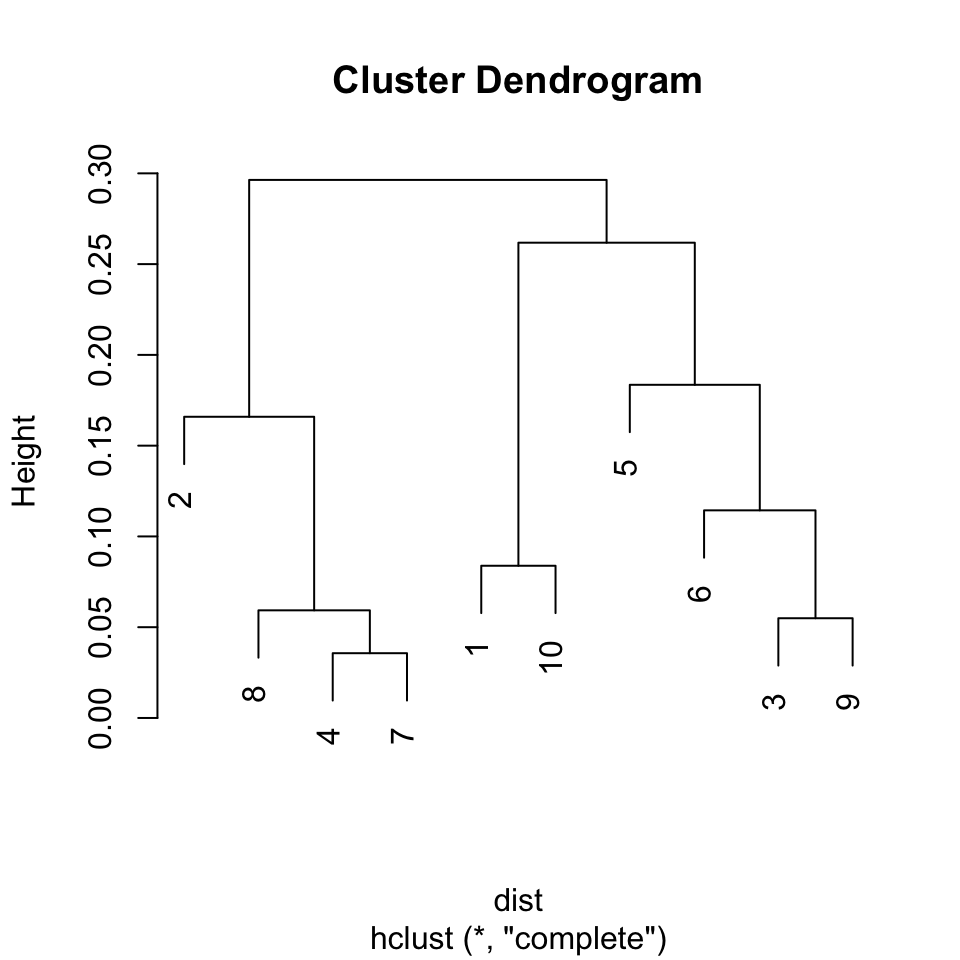

```r
dist <- 1 - LPC::corr.bestlag(simdata[11:20, ], timepoints = timepoints, max.lag = 2, penalty = "low", iter = 10)$corr
plot(hclust(dist))
```

These can also be assigned to cluster using cutree function. The example of cluster assignement with 3 cluster size

```r
dist <- 1 - LPC::corr.bestlag(simdata[11:20, ], timepoints = timepoints, max.lag = 2, penalty = "low", iter = 10)$corr
cutree(hclust(dist), k = 3)
```

```
##  [1] 1 2 3 2 3 3 2 2 3 1
```

# 3 Contributors

We have benefited in the development of LPC from the help and feedback of many individuals, including but not limited to:

Gitter Lab Members, James Dowell, Ron Stewart

# 5 FAQ

- How to speed up LPC for low penalty with large gene set?

```r
comb <- function(x, ...) {
  lapply(seq_along(x),
         function(i) c(x[[i]], lapply(list(...), function(y) y[[i]])))
}



data <- simdata[1:10, ]
iter <- 10
allC <- findC(timepoints = timepoints, max.lag = 2)

##setting clusters
core <- parallel::detectCores() - 1
cl <- parallel::makeCluster(core)
doParallel::registerDoParallel(cl)


##results from multiple C
result <- foreach(i = 1:iter, .combine='comb', .multicombine=TRUE,
                .init=list(list(), list())) %dopar% {
            lags <- best.lag(data, max.lag = 3, timepoints = timepoints, C = allC[i])
            new.data <- prep.data(data = data, lags = lags, timepoints = timepoints)
            corr <- comp.corr(new.data$data, new.data$time, C = allC[i])
            return(list(corr, lags))
}
allcorr <- result[[1]]
alllags <- result[[2]]

##picking best C
val <- rep(NA, (length(iter) - 1))
for(i in 1:(iter - 1)){
  val[i] <- sum((as.vector(allcorr[[i + 2]]) - as.vector(allcorr[[i + 1]]))^2)
}

result <- list(corr = allcorr[[which.min(val) + 1]], lags = alllags[[which.min(val) + 1]], C = values[which.min(val) + 1])
```